# Presence or absence of a prefrontal sulcus is linked to reasoning performance during child development

analyses run by EH Willbrand & WI Voorhies

2022

#### Libraries

Requirements: packages below must be installed to load.

## Morphological comparisons

### Incidence rates of pimfs components

1. Does the number of components vary between hemispheres?
2. Does the number of components vary within hemisphere?
3. Does component type vary with hemispheres

Sulci were manually identified as component(s) of the pimfs in each hemisphere according to previous work (Fig 1A; Supplementary Fig. 1; (Amiez and Petrides, 2007; Petrides, 2019; Voorhies et al., 2021). We confirmed our prior observation that the pimfs was highly variable (Fig. 1B): in a given hemisphere, there could be zero, (left = 2.78% of participants; right = 8.33%), one (left: 22.22%; right: 25%), or two components (left: 75%; right: 66.67%; left: $\chi^2$ = 60.33, df = 2, *p* < 0.001 right: $\chi^2$ = 39, df = 2, *p* < 0.001); no hemispheric asymmetry: *p* = = 0.302. Based on published criteria (Petrides, 2013), we further defined pimfs components as either dorsal (pimfs-d) or ventral (pimfs-v) and assessed the prevalence of each component (Fig. 1B). Numerically, a single dorsal component was more frequent than a single ventral one, but statistically these profiles were equally frequent ($\chi^2$ ≥ .89, p > .30 for both hemispheres).

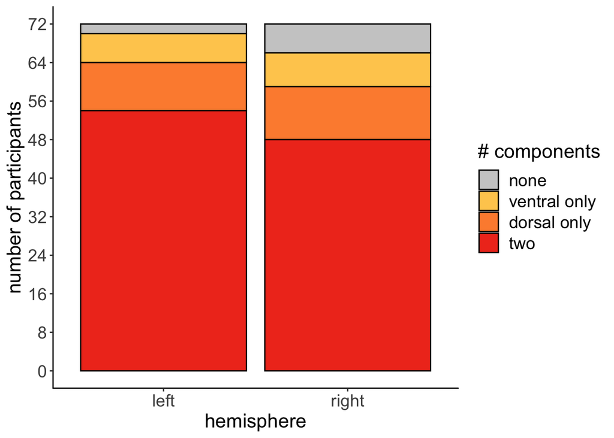

## Number of components and Behavior

### model 1: Number of components

### Does the number of the pimfs components relate to reasoning scores?

- 2-way ANCOVA controlling for assessment age
- DV: relational reasoning score = *MatrixR*
- IV1: number of pimfs components in left hemisphere (two/<two) = *num_comp_lh*
- IV2: number of pimfs components in right hemisphere (two/<two) = *num_comp_rh*
- covariate: Assessment Age = *AssessmentAge*

|  | Effect | DFn | DFd | F | p | p<.05 | ges |
| --- | --- | --- | --- | --- | --- | --- | --- |
| 1 | num_comp_lh | 1 | 67 | 4.175 | 0.04500000000 | * | 0.059 |
| 2 | num_comp_rh | 1 | 67 | 2.628 | 0.11000000000 |  | 0.038 |
| 3 | AssessmentAge | 1 | 67 | 44.945 | 0.00000000511 | * | 0.401 |
| 4 | num_comp_lh:num_comp_rh | 1 | 67 | 1.066 | 0.30600000000 |  | 0.016 |

An analysis of covariance (ANCOVA; including age as a covariate) found that the number of pimfs components in left ( $F(1,67) =$ 4.175, *p*= 0.045, $\eta^2_G$ = 0.06), but not right ($F(1,67) =$ 2.628, *p*= 0.110, $\eta^2_G$ = 0.04), hemisphere was related to reasoning performance. Specifically, individuals with two pimfs components in their left hemisphere performed better (mean±std = 26.80 ± 5.21) compared to those with 0 or 1 component (mean±std = 22.22 ± 7.04; Fig. 2A, right)

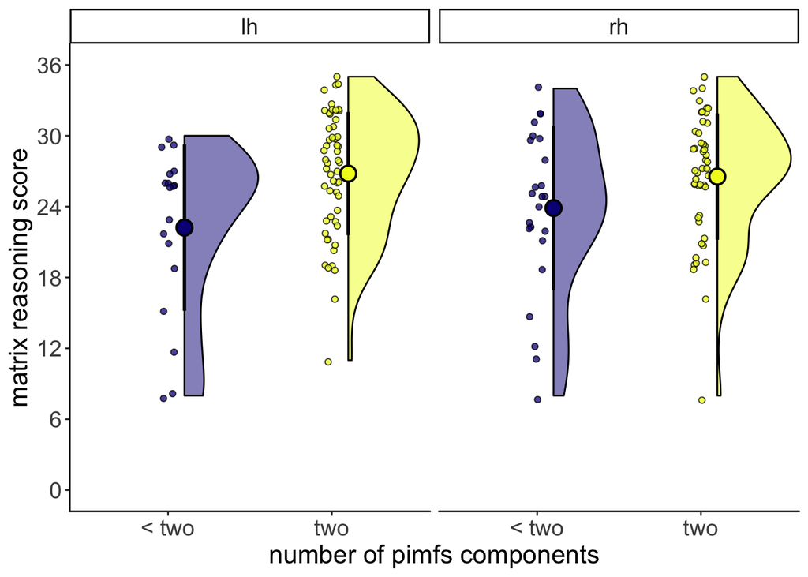

### model 2 (behavioral analysis)

### Does the presence of the dorsal and/or ventral component of the pimfs components relate to reasoning scores?

- 4-way ANCOVA controlling for assessment age
- DV: relational reasoning score = *MatrixR*
- IV1: presence of ventral component in left hemisphere (yes/no) = *ventral_lh*
- IV2: number of ventral component in right hemisphere (yes/no) = *ventral_rh*
- IV3: presence of dorsal component in left hemisphere (yes/no) = *dorsal_lh*
- IV4: number of dorsal component in right hemisphere (yes/no) = *dorsal_rh*
- covariate: Assessment Age = *AssessmentAge*

|  | Effect | DFn | DFd | F | p | p<.05 | ges |
| --- | --- | --- | --- | --- | --- | --- | --- |
| 1 | ventral_lh | 1 | 66 | 5.095 | 0.02700000000 | * | 0.072 |
| 2 | ventral_rh | 1 | 66 | 1.305 | 0.25700000000 |  | 0.019 |
| 3 | dorsal_lh | 1 | 66 | 0.091 | 0.76400000000 |  | 0.001 |
| 4 | dorsal_rh | 1 | 66 | 0.515 | 0.47600000000 |  | 0.008 |
| 5 | AssessmentAge | 1 | 66 | 49.951 | 0.00000000123 | * | 0.431 |

Although the presence of a left dorsal component significantly related to *Assessment Age* (*p*= 0.021), this moderate collinearity not affect the model results (vif < 5). *Assessment Age* did not relate to any other predictor (*p*s > .20).

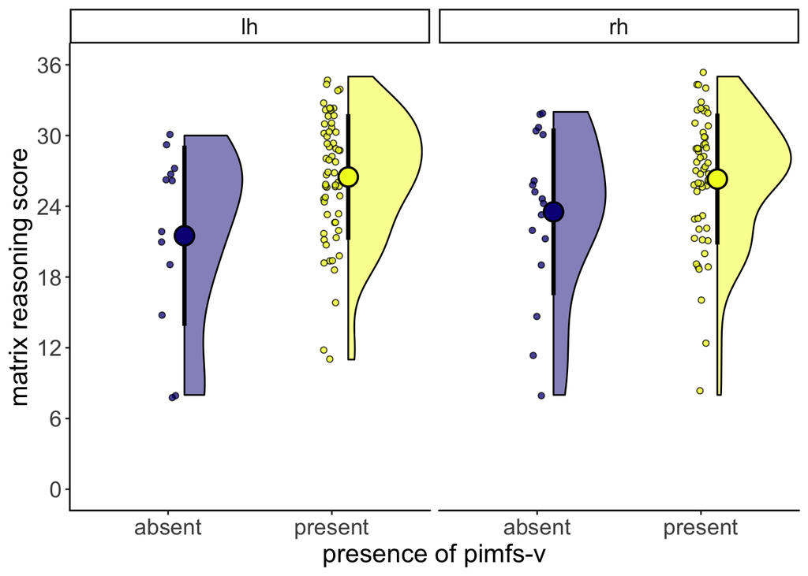

### Control analyses

Consider whether the same effects are present for alternate DV metrics. Specifically working memory and processing speed.

#### Cross out

|  | Effect | DFn | DFd | F | p | p<.05 | ges |
| --- | --- | --- | --- | --- | --- | --- | --- |
| 1 | ventral_lh | 1 | 68 | 0.428 | 0.51500000000000001332 |  | 0.006 |
| 2 | AssessmentAge | 1 | 68 | 145.246 | 0.00000000000000000154 | * | 0.681 |

#### Digit forwards

|  | Effect | DFn | DFd | F | p | p<.05 | ges |
| --- | --- | --- | --- | --- | --- | --- | --- |
| 1 | ventral_lh | 1 | 61 | 0.255 | 0.61500000 |  | 0.004 |
| 2 | AssessmentAge | 1 | 61 | 28.588 | 0.00000142 | * | 0.319 |

#### Digit backwards

|  | Effect | DFn | DFd | F | p | p<.05 | ges |
| --- | --- | --- | --- | --- | --- | --- | --- |
| 1 | ventral_lh | 1 | 61 | 0.067 | 0.79600000 |  | 0.001 |
| 2 | AssessmentAge | 1 | 61 | 28.954 | 0.00000124 | * | 0.322 |

Follow-up analyses with additional behavioral measures revealed that the presence of the left pimfs-v was not related to processing speed or phonological working memory (digit span forwards and backward; all *p*s > 0.5), suggesting some degree of specificity in this brain-behavior relation.

### Matching on age.

| ventral_lh | median | sd |
| --- | --- | --- |
| no_ventral | 8.810 | 4.225439 |
| yes_ventral | 11.775 | 3.525843 |

#### original data

```
##               Means Treated Means Control Std. Mean Diff. Var. Ratio eCDF Mean
## distance          0.1938137     0.1612373       0.4458412   1.499208 0.1584507
## AssessmentAge    10.7008333    12.3196667      -0.3831160   1.436209 0.1584507
##                eCDF Max Std. Pair Dist.
## distance      0.3666667              NA
## AssessmentAge 0.3666667              NA
```

#### Matched data

```
##               Means Treated Means Control Std. Mean Diff. Var. Ratio  eCDF Mean
## distance          0.1938137     0.1942675    -0.006210974   1.033634 0.02112676
## AssessmentAge    10.7008333    10.6643333     0.008638155   1.063482 0.02112676
##                 eCDF Max Std. Pair Dist.
## distance      0.08333333      0.07585360
## AssessmentAge 0.08333333      0.08618434
```

#### run weighted regression model on matched data

```
##
## Call:
## lm(formula = MatrixR ~ ventral_lh + AssessmentAge, data = m.data,
##     weights = m.data$weights)
##
## Weighted Residuals:
##      Min       1Q   Median       3Q      Max
## -11.5553  -2.4629   0.3107   2.8079   8.6863
##
## Coefficients:
##                       Estimate Std. Error t value     Pr(>|t|)
## (Intercept)            10.6935     2.0414   5.238 0.0000041437
## ventral_lhyes_ventral   3.6869     1.4129   2.609       0.0123
## AssessmentAge           1.0099     0.1527   6.613 0.0000000382
##
## Residual standard error: 4.239 on 45 degrees of freedom
## Multiple R-squared:  0.5284, Adjusted R-squared:  0.5074
## F-statistic: 25.21 on 2 and 45 DF,  p-value: 0.00000004532
```

#### A model with just age on matched data

```
##
## Call:
## lm(formula = MatrixR ~ AssessmentAge, data = m.data, weights = m.data$weights)
##
## Weighted Residuals:
##      Min       1Q   Median       3Q      Max
## -12.7856  -2.1399   0.8019   3.0916  10.2715
##
## Coefficients:
##               Estimate Std. Error t value      Pr(>|t|)
## (Intercept)    13.4754     1.8475   7.294 0.00000000331
## AssessmentAge   1.0083     0.1621   6.222 0.00000013445
##
## Residual standard error: 4.498 on 46 degrees of freedom
## Multiple R-squared:  0.457,  Adjusted R-squared:  0.4452
## F-statistic: 38.71 on 1 and 46 DF,  p-value: 0.0000001344
```

#### compare nested models

|  | Res.Df | RSS | Df | Sum of Sq | F | Pr(>F) |
| --- | --- | --- | --- | --- | --- | --- |
| 1 | 46 | 930.8687 | NA | NA | NA | NA |
| 2 | 45 | 808.5341 | 1 | 122.3345 | 6.808686 | 0.01227254 |

#### Visualize matched results

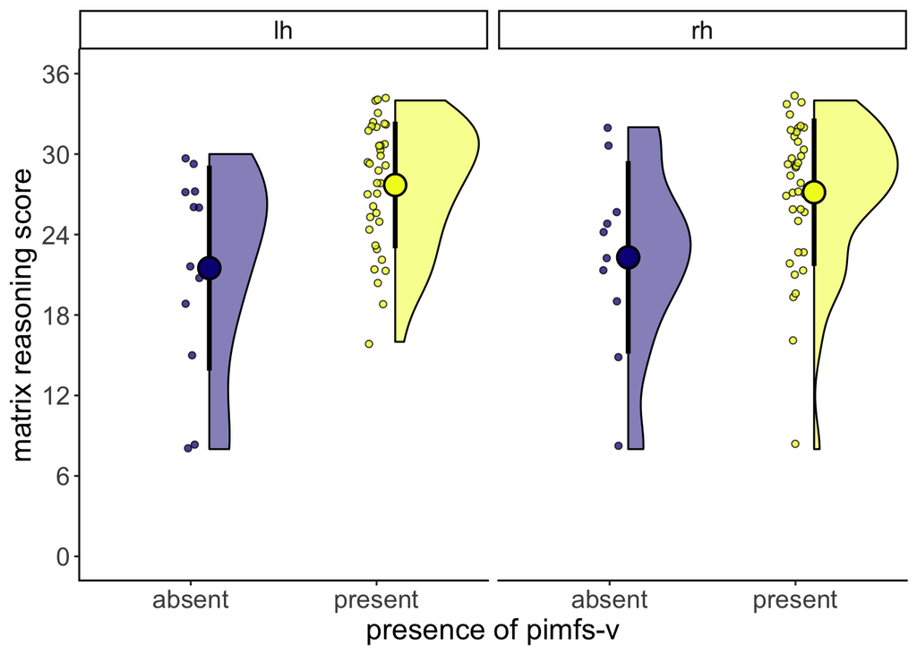

Due to differences in the sample size and age distribution of the two groups (median(sd)present = 11.775(3.53) , median(sd)absent = 8.81(4.23))), we sought to further confirm the effect of presence/absence of the left pimfs-v on reasoning performance. To this end, we employed variable ratio matching (Materials and Methods) to create an age-matched sample that consisted of the original 12 participants without a left pimfs-v and the 36 age-matched participants with a left pimfs-v (mean age = 10.66). A weighted regression in the matched sample with left pimfs-v presence and age as predictors of reasoning revealed that the presence of the left pimfs-v remained significant (ß = 3.69, *t* = 2.61, *p* = .012; Fig. 2A, right). Critically, this model explained significantly more variance than a model with age alone in the same sample (pimfs: adjusted $R^2$=0.51, *p* < .001; age: adjusted $R^2$ = 0.45, *p*<.001; model comparison: *p*=.012).

### LOOCV pred vs measured

```
## Linear Regression
##
## 48 samples
##  2 predictor
##
## No pre-processing
## Resampling: Leave-One-Out Cross-Validation
## Summary of sample sizes: 47, 47, 47, 47, 47, 47, ...
## Resampling results:
##
##   RMSE      Rsquared   MAE
##   4.406162  0.4803743  3.412449
##
## Tuning parameter 'intercept' was held constant at a value of TRUE
```

```
## Linear Regression
##
## 48 samples
##  1 predictor
##
## No pre-processing
## Resampling: Leave-One-Out Cross-Validation
## Summary of sample sizes: 47, 47, 47, 47, 47, 47, ...
## Resampling results:
##
##   RMSE      Rsquared   MAE
##   4.620179  0.4227914  3.679504
##
## Tuning parameter 'intercept' was held constant at a value of TRUE
```

## Surface area and Behavior

### model 3 (behavioral analysis)

### Does the surface area of the overall pimfs relate to reasoning scores?

- multiple linear model controlling for assessment age
- DV: relational reasoning score = *MatrixR*
- IV1: surface area of pimfs in left hemisphere = *pimfs_sa_lh*
  - two components -> combine surface area of each
- IV2: surface area of pimfs in right hemisphere = *pimfs_sa_rh*
- control: Assessment Age = *AssessmentAge*

```
##
## Call:
## lm(formula = MatrixR ~ pimfs_sa_lh * pimfs_sa_rh + AssessmentAge,
##     data = surface_area_analyses)
##
## Residuals:
##      Min       1Q   Median       3Q      Max
## -13.3450  -2.8722   0.2793   3.1404   8.9609
##
## Coefficients:
##                            Estimate  Std. Error t value      Pr(>|t|)
## (Intercept)              8.84111554  2.23752797   3.951       0.00019
## pimfs_sa_lh              0.01126264  0.00480214   2.345       0.02198
## pimfs_sa_rh              0.01055184  0.00569352   1.853       0.06824
## AssessmentAge            1.00243734  0.14599616   6.866 0.00000000263
## pimfs_sa_lh:pimfs_sa_rh -0.00002075  0.00001319  -1.573       0.12033
##
## Residual standard error: 4.298 on 67 degrees of freedom
## Multiple R-squared:  0.5177, Adjusted R-squared:  0.4889
## F-statistic: 17.98 on 4 and 67 DF,  p-value: 0.0000000004502
```

#### Partial $R^2$

```r
# partial r for pimfs_sa_lh
nested_lm <- lm(MatrixR ~ pimfs_sa_rh + pimfs_sa_lh:pimfs_sa_rh + AssessmentAge,
                         data = surface_area_analyses)
# get summary of models
sum_sa_lm <- anova(surface_area.model)
sum_nested_lm <- anova(nested_lm)

# compute partial R^2
R2_partial<- (sum_nested_lm["Residuals", "Sum Sq"] - sum_sa_lm["Residuals", "Sum Sq"])/sum_nested_lm["Residuals", "Sum Sq"]

r_partial <- sqrt(R2_partial)
# R^2 partial = .08 --> r = .28
```

$R^2$ partial = 0.0758699 –> r partial = 0.2754449

#### age alone

```
##
## Call:
## lm(formula = MatrixR ~ AssessmentAge, data = surface_area_analyses)
##
## Residuals:
##     Min      1Q  Median      3Q     Max
## -12.291  -2.958   0.853   3.475   6.502
##
## Coefficients:
##               Estimate Std. Error t value        Pr(>|t|)
## (Intercept)    12.1936     1.8035   6.761 0.0000000033943
## AssessmentAge   1.1170     0.1433   7.797 0.0000000000433
##
## Residual standard error: 4.43 on 70 degrees of freedom
## Multiple R-squared:  0.4648, Adjusted R-squared:  0.4571
## F-statistic: 60.79 on 1 and 70 DF,  p-value: 0.00000000004325
```

#### model comparison

|  | Res.Df | RSS | Df | Sum of Sq | F | Pr(>F) |
| --- | --- | --- | --- | --- | --- | --- |
| 1 | 70 | 1373.535 | NA | NA | NA | NA |
| 2 | 67 | 1237.633 | 3 | 135.9016 | 2.452371 | 0.07089015 |

### Perform the same analysis using cross-validation techniques

Utitlize two cross-validation methodologies.

#### 5-fold

```
## Linear Regression
##
## 72 samples
##  3 predictor
##
## No pre-processing
## Resampling: Cross-Validated (5 fold, repeated 10 times)
## Summary of sample sizes: 58, 57, 58, 58, 57, 57, ...
## Resampling results:
##
##   RMSE      Rsquared   MAE
##   4.334325  0.5135619  3.471538
##
## Tuning parameter 'intercept' was held constant at a value of TRUE
```

#### age alone

```
## Linear Regression
##
## 72 samples
##  1 predictor
##
## No pre-processing
## Resampling: Cross-Validated (5 fold, repeated 10 times)
## Summary of sample sizes: 58, 57, 58, 58, 57, 57, ...
## Resampling results:
##
##   RMSE      Rsquared   MAE
##   4.404334  0.4894899  3.580517
##
## Tuning parameter 'intercept' was held constant at a value of TRUE
```

#### LOOCV

```
## Linear Regression
##
## 72 samples
##  3 predictor
##
## No pre-processing
## Resampling: Leave-One-Out Cross-Validation
## Summary of sample sizes: 71, 71, 71, 71, 71, 71, ...
## Resampling results:
##
##   RMSE      Rsquared   MAE
##   4.452396  0.4468371  3.526581
##
## Tuning parameter 'intercept' was held constant at a value of TRUE
```

#### age alone

```
## Linear Regression
##
## 72 samples
##  1 predictor
##
## No pre-processing
## Resampling: Leave-One-Out Cross-Validation
## Summary of sample sizes: 71, 71, 71, 71, 71, 71, ...
## Resampling results:
##
##   RMSE      Rsquared   MAE
##   4.506687  0.4308633  3.631299
##
## Tuning parameter 'intercept' was held constant at a value of TRUE
```

#### repeate analysis with surface area values normed by total frontal surface area

The prefrontal cortex has been reported to increase in total surface area with age so we repeat the same analysis with sulcal surface area values normed by total prefrontal lobe SA.

```
##
## Call:
## lm(formula = MatrixR ~ pimfs_sa_normed_lh * pimfs_sa_normed_rh +
##     AssessmentAge, data = surface_area_analyses_norm)
##
## Residuals:
##      Min       1Q   Median       3Q      Max
## -13.1208  -3.0547   0.2747   3.5768   8.3512
##
## Coefficients:
##                                          Estimate  Std. Error t value
## (Intercept)                                9.3426      2.3554   3.966
## pimfs_sa_normed_lh                       245.3643    135.8263   1.806
## pimfs_sa_normed_rh                       207.8960    159.4891   1.304
## AssessmentAge                              1.0360      0.1474   7.028
## pimfs_sa_normed_lh:pimfs_sa_normed_rh -11246.9769  10073.5810  -1.116
##                                            Pr(>|t|)
## (Intercept)                                 0.00018
## pimfs_sa_normed_lh                          0.07534
## pimfs_sa_normed_rh                          0.19686
## AssessmentAge                         0.00000000135
## pimfs_sa_normed_lh:pimfs_sa_normed_rh       0.26820
##
## Residual standard error: 4.386 on 67 degrees of freedom
## Multiple R-squared:  0.4979, Adjusted R-squared:  0.4679
## F-statistic: 16.61 on 4 and 67 DF,  p-value: 0.000000001677
```

Despite there being a correlation between assessment age and pimfs surface area in the left hemisphere, this moderate collinearity does not affect the model (vif < 5).

The multiple linear regression revealed that the three predictors accounted for 49% of the variance in the matrix reasoning scores, $F(4,67)=$ 17.98, *p* < .0001, adjusted $R^2$ = .49. Importantly, the *MatrixR* score was associated with the *surface area of the left pimfs* ($\beta =$ 0.011, *t* = 2.35, *p* = .022) and *Assessment Age* ($\beta =$ 1, *t* = 6.87, *p* < .0001), but not the *surface area of the right pimfs* ($\beta =$ 0.011, *t* = 1.85, *p* = .068).

A repeated K-fold (5 fold, 10 repeats) and leave-one-out cross-validation (looCV) confirmed the predictiveness of the pimfs model (5-fold: $R^2$ = 0.51, $RMSE$ = 4.33; looCV: $R^2$ = 0.45, $RMSE$ = 4.45), which was only slightly better than age alone (5-fold: $R^2$ = 0.49, $RMSE$ = 4.4; looCV: $R^2$ = 0.43, $RMSE$ = 4.51). Thus, the presence or absence of pimfs-v may be more directly related to reasoning than overall surface area.

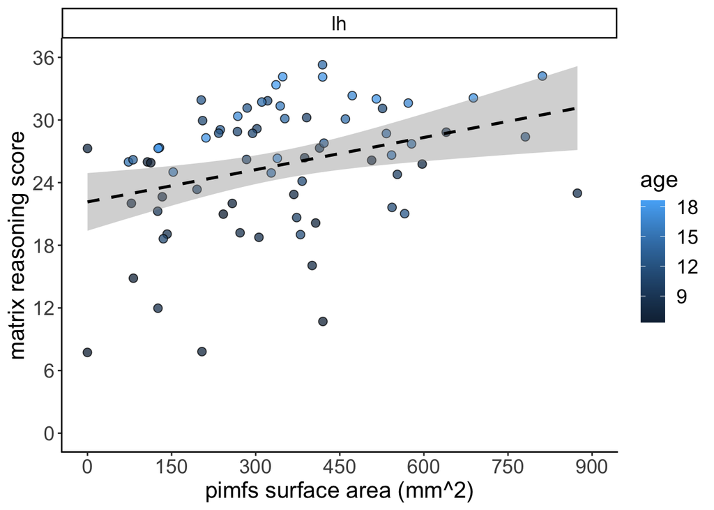

# Supplementary Age Plots

```
##
##  Welch Two Sample t-test
##
## data:  pimfs_components_test$AssessmentAge by pimfs_components_test$num_comp_lh
## t = -1.9657, df = 28.55, p-value = 0.05913
## alternative hypothesis: true difference in means between group less_two and group two is not equal to 0
## 95 percent confidence interval:
##  -3.97766855  0.08026114
## sample estimates:
## mean in group less_two      mean in group two
##               10.58833               12.53704
```

```
##
##  Welch Two Sample t-test
##
## data:  pimfs_components_test$AssessmentAge by pimfs_components_test$num_comp_rh
## t = -1.0173, df = 47.223, p-value = 0.3142
## alternative hypothesis: true difference in means between group less_two and group two is not equal to 0
## 95 percent confidence interval:
##  -2.7534264  0.9038431
## sample estimates:
## mean in group less_two      mean in group two
##               11.43333               12.35812
```

```
##
##  Welch Two Sample t-test
##
## data:  pimfs_components_test$AssessmentAge by pimfs_components_test$dorsal_lh
## t = -2.6975, df = 10.796, p-value = 0.02106
## alternative hypothesis: true difference in means between group no_dorsal and group yes_dorsal is not equal to 0
## 95 percent confidence interval:
##  -5.0739381 -0.5085619
## sample estimates:
##  mean in group no_dorsal mean in group yes_dorsal
##                  9.56875                 12.36000
```

```
##
##  Welch Two Sample t-test
##
## data:  pimfs_components_test$AssessmentAge by pimfs_components_test$dorsal_rh
## t = -0.7069, df = 16.982, p-value = 0.4892
## alternative hypothesis: true difference in means between group no_dorsal and group yes_dorsal is not equal to 0
## 95 percent confidence interval:
##  -3.309801  1.648601
## sample estimates:
##  mean in group no_dorsal mean in group yes_dorsal
##                 11.36923                 12.19983
```

```
##
##  Welch Two Sample t-test
##
## data:  pimfs_components_test$AssessmentAge by pimfs_components_test$ventral_lh
## t = -1.2434, df = 14.226, p-value = 0.2338
## alternative hypothesis: true difference in means between group no_ventral and group yes_ventral is not equal to 0
## 95 percent confidence interval:
##  -4.407075  1.169408
## sample estimates:
##  mean in group no_ventral mean in group yes_ventral
##                  10.70083                  12.31967
```

```
##
##  Welch Two Sample t-test
##
## data:  pimfs_components_test$AssessmentAge by pimfs_components_test$ventral_rh
## t = -0.75831, df = 26.063, p-value = 0.4551
## alternative hypothesis: true difference in means between group no_ventral and group yes_ventral is not equal to 0
## 95 percent confidence interval:
##  -2.916502  1.344417
## sample estimates:
##  mean in group no_ventral mean in group yes_ventral
##                  11.44941                  12.23545
```

```
##
##  Pearson's product-moment correlation
##
## data:  surface_area_analyses$pimfs_sa_lh and surface_area_analyses$AssessmentAge
## t = 2.073, df = 70, p-value = 0.04185
## alternative hypothesis: true correlation is not equal to 0
## 95 percent confidence interval:
##  0.00935446 0.44725102
## sample estimates:
##       cor
## 0.2405018
```

```
##
##  Pearson's product-moment correlation
##
## data:  surface_area_analyses$pimfs_sa_rh and surface_area_analyses$AssessmentAge
## t = 1.7384, df = 70, p-value = 0.08654
## alternative hypothesis: true correlation is not equal to 0
## 95 percent confidence interval:
##  -0.0296317  0.4155189
## sample estimates:
##       cor
## 0.2034334
```